# Practical machine learning - human activity recognition

Sigve Nakken

23 Sep 2015

#### Background

Using devices such as Jawbone Up, Nike FuelBand, and Fitbit it is now possible to collect a large amount of data about personal activity relatively inexpensively. These type of devices are part of the quantified self movement – a group of enthusiasts who take measurements about themselves regularly to improve their health, to find patterns in their behavior, or because they are tech geeks. One thing that people regularly do is quantify how much of a particular activity they do, but they rarely quantify how well they do it. In this project, our goal will be to use data from accelerometers on the belt, forearm, arm, and dumbell of 6 participants. They were asked to perform barbell lifts correctly and incorrectly in 5 different ways. More information is available from the website http://groupware.les.inf.puc-rio.br/har

#### Download and read raw datasets

```r
training_dataset_file <- 'pml-training.csv'
testing_dataset_file <- 'pml-testing.csv'

if (!file.exists(training_dataset_file)) {
  download.file("https://d396qusza40orc.cloudfront.net/predmachlearn/pml-training.csv", training_dataset_file, quiet=T,method="curl")
}

if (!file.exists(testing_dataset_file)){
  download.file("https://d396qusza40orc.cloudfront.net/predmachlearn/pml-testing.csv",testing_dataset_file,quiet=T,method="curl")
}

pml_training_all <- read.csv(file=training_dataset_file,stringsAsFactors = F,header=T,na.strings=c("",NA,"#DIV/0!"))
pml_testing_all <- read.csv(file=testing_dataset_file,stringsAsFactors = F,header=T,na.strings=c("",NA,"#DIV/0!"))
```

#### Load required libraries

```r
suppressPackageStartupMessages(require(dplyr))
suppressPackageStartupMessages(require(magrittr))
suppressPackageStartupMessages(require(caret))
suppressPackageStartupMessages(require(randomForest))
suppressPackageStartupMessages(require(rpart))
suppressPackageStartupMessages(require(rattle))
```

#### Data cleaning & creation of training/validation set

Get only columns with zero NA’s in the training set - to be used as predictor candidates:

```r
## get only columns with zero NAs in trainingset - to be used as predictor candidates
pml_training_cleaned <- pml_training_all[, colSums(is.na(pml_training_all)) == 0]
dim(pml_training_cleaned)
```

```
## [1] 19622    60
```

Now, I further remove predictor candidates with zero variance using *nearZeroVar* of the caret package:

```r
nsv <- nearZeroVar(pml_training_cleaned, saveMetrics = T)
skippedPredictors <- row.names(nsv[nsv$nzv == TRUE,])
nonSkippedPredictors <- pml_training_cleaned[!(colnames(pml_training_cleaned) %in% skippedPredictors)]
```

Finally, I ignore predictors that appear non relevant to the outcome that is to be predicted (timestamp, username, window etc):

```r
pml_training_df <- nonSkippedPredictors %>% dplyr::select(-X, -user_name, -raw_timestamp_part_1, -raw_timestamp_part_2, -cvtd_timestamp)
dim(pml_training_df)
```

```
## [1] 19622    54
```

Creation of training and validation dataset using *createDataPartition*:

```r
in_train <- createDataPartition(y = pml_training_df$classe, p = 0.6, list=F)
pml_train <- pml_training_df[in_train,]
pml_test <- pml_training_df[-in_train,]

all.equal(names(pml_train),names(pml_test))
```

```
## [1] TRUE
```

#### Correlation between predictors - visualization

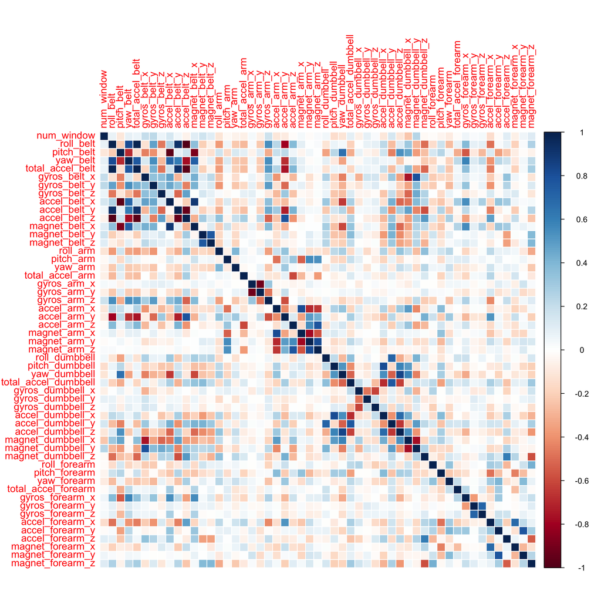

```r
corrPlot <- cor(pml_train[,-54])
corrplot::corrplot(corrPlot,method="color")
```

#### Model building and training

```r
## set seed
set.seed(1234)
```

I start with an attempt to model the data based on a decision tree (using *rpart* library). This type of model is favorable in terms of interpretation and could thus provide valuable insight into the predictors that matter for the *classe* variable: Here, I also employ cross-validation (k = 5), and preprocessing (scaling and centering of variables) as part of model training.

```r
modFit_tree <- train(as.factor(classe) ~ ., data=pml_train, method="rpart",trControl = trainControl(method="cv", number=5), preProc=c("center", "scale"))
modFit_tree
```

```
## CART
##
## 11776 samples
##    53 predictor
##     5 classes: 'A', 'B', 'C', 'D', 'E'
##
## Pre-processing: centered, scaled
## Resampling: Cross-Validated (5 fold)
## Summary of sample sizes: 9420, 9420, 9420, 9422, 9422
## Resampling results across tuning parameters:
##
##   cp          Accuracy   Kappa       Accuracy SD  Kappa SD
##   0.03731609  0.5390627  0.40745303  0.04274343   0.06303441
##   0.06197595  0.3916345  0.16783450  0.05634332   0.09475844
##   0.11485524  0.3470674  0.09602423  0.03511668   0.05380309
##
## Accuracy was used to select the optimal model using  the largest value.
## The final value used for the model was cp = 0.03731609.
```

Now, plot the tree and look at the accuracy (out-of-sample performance) within the validation set:

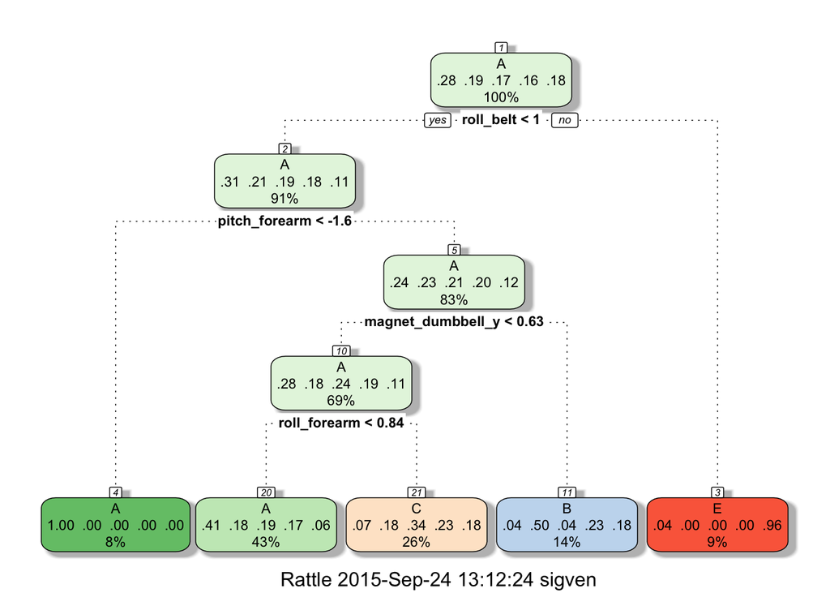

```r
fancyRpartPlot(modFit_tree$finalModel)
```

```r
tree_predictions <- predict.train(modFit_tree, newdata = pml_test)
confusionMatrix(tree_predictions, pml_test$classe)
```

```
## Confusion Matrix and Statistics
##
##           Reference
## Prediction    A    B    C    D    E
##          A 1979  631  625  565  184
##          B   49  517   58  240  190
##          C  170  370  685  481  377
##          D    0    0    0    0    0
##          E   34    0    0    0  691
##
## Overall Statistics
##
##                Accuracy : 0.4935
##                  95% CI : (0.4824, 0.5046)
##     No Information Rate : 0.2845
##     P-Value [Acc > NIR] : < 2.2e-16
##
##                   Kappa : 0.339
##  Mcnemar's Test P-Value : NA
##
## Statistics by Class:
##
##                      Class: A Class: B Class: C Class: D Class: E
## Sensitivity            0.8866  0.34058  0.50073   0.0000  0.47920
## Specificity            0.6429  0.91514  0.78419   1.0000  0.99469
## Pos Pred Value         0.4967  0.49051  0.32885      NaN  0.95310
## Neg Pred Value         0.9345  0.85262  0.88149   0.8361  0.89454
## Prevalence             0.2845  0.19347  0.17436   0.1639  0.18379
## Detection Rate         0.2522  0.06589  0.08731   0.0000  0.08807
## Detection Prevalence   0.5078  0.13434  0.26549   0.0000  0.09240
## Balanced Accuracy      0.7648  0.62786  0.64246   0.5000  0.73694
```

Considering the poor performance of the decision tree, I try to improve prediction accuracy by employing a tree-based model based on boosting. This model also employs cross-validation (k = 5), as wella as preprocessing of predictor variables (centering and scaling):

```r
modFit_boosting <- train(as.factor(classe) ~ ., data=pml_train, method="gbm",verbose =F, trControl = trainControl(method="cv", number=5), preProc=c("center", "scale"))
modFit_boosting
```

```
## Stochastic Gradient Boosting
##
## 11776 samples
##    53 predictor
##     5 classes: 'A', 'B', 'C', 'D', 'E'
##
## Pre-processing: centered, scaled
## Resampling: Cross-Validated (5 fold)
## Summary of sample sizes: 9420, 9422, 9420, 9421, 9421
## Resampling results across tuning parameters:
##
##   interaction.depth  n.trees  Accuracy   Kappa      Accuracy SD
##   1                   50      0.7642696  0.7010832  0.014644706
##   1                  100      0.8341564  0.7900511  0.011314019
##   1                  150      0.8729636  0.8392083  0.010965656
##   2                   50      0.8794168  0.8472582  0.009204405
##   2                  100      0.9370760  0.9203747  0.004227252
##   2                  150      0.9622113  0.9521941  0.002616968
##   3                   50      0.9329153  0.9150936  0.005953051
##   3                  100      0.9699390  0.9619664  0.001318038
##   3                  150      0.9850543  0.9810936  0.001140360
##   Kappa SD
##   0.018616376
##   0.014256496
##   0.013841964
##   0.011715136
##   0.005352681
##   0.003301463
##   0.007535224
##   0.001663159
##   0.001440292
##
## Tuning parameter 'shrinkage' was held constant at a value of 0.1
##
## Tuning parameter 'n.minobsinnode' was held constant at a value of 10
## Accuracy was used to select the optimal model using  the largest value.
## The final values used for the model were n.trees = 150,
##  interaction.depth = 3, shrinkage = 0.1 and n.minobsinnode = 10.
```

```r
boost_predictions <- predict.train(modFit_boosting, newdata = pml_test)
confusionMatrix(boost_predictions, pml_test$classe)
```

```
## Confusion Matrix and Statistics
##
##           Reference
## Prediction    A    B    C    D    E
##          A 2228   26    0    2    0
##          B    3 1467    8    2    4
##          C    0   20 1351   20    1
##          D    1    4    7 1262   22
##          E    0    1    2    0 1415
##
## Overall Statistics
##
##                Accuracy : 0.9843
##                  95% CI : (0.9813, 0.987)
##     No Information Rate : 0.2845
##     P-Value [Acc > NIR] : < 2.2e-16
##
##                   Kappa : 0.9802
##  Mcnemar's Test P-Value : NA
##
## Statistics by Class:
##
##                      Class: A Class: B Class: C Class: D Class: E
## Sensitivity            0.9982   0.9664   0.9876   0.9813   0.9813
## Specificity            0.9950   0.9973   0.9937   0.9948   0.9995
## Pos Pred Value         0.9876   0.9885   0.9705   0.9738   0.9979
## Neg Pred Value         0.9993   0.9920   0.9974   0.9963   0.9958
## Prevalence             0.2845   0.1935   0.1744   0.1639   0.1838
## Detection Rate         0.2840   0.1870   0.1722   0.1608   0.1803
## Detection Prevalence   0.2875   0.1891   0.1774   0.1652   0.1807
## Balanced Accuracy      0.9966   0.9819   0.9906   0.9881   0.9904
```

Finally, I attempt a third model which is based on the *Random Forest* methodology, an approach which is robust against correlated covariates. In order to limit the execution time of the algorithm, I set *ntree* to 400 (this could come at a trade-off of less overall accuracy). I also do not employ any cross-validation during model tranining (advice from TA)

```r
tgrid <- expand.grid(mtry=c(6))
modFit_rf <- train(as.factor(classe) ~ ., data=pml_train, method="rf",prox=T, ntree=400, tuneGrid = tgrid, trControl = trainControl(method="none"), preProc=c("center", "scale"))
modFit_rf
```

```
## Random Forest
##
## 11776 samples
##    53 predictor
##     5 classes: 'A', 'B', 'C', 'D', 'E'
##
## Pre-processing: centered, scaled
## Resampling: None
```

```r
rf_predictions <- predict.train(modFit_rf, newdata = pml_test)
confusionMatrix(rf_predictions, pml_test$classe)
```

```
## Confusion Matrix and Statistics
##
##           Reference
## Prediction    A    B    C    D    E
##          A 2232    7    0    0    0
##          B    0 1510    4    0    0
##          C    0    1 1364   14    0
##          D    0    0    0 1272    2
##          E    0    0    0    0 1440
##
## Overall Statistics
##
##                Accuracy : 0.9964
##                  95% CI : (0.9948, 0.9976)
##     No Information Rate : 0.2845
##     P-Value [Acc > NIR] : < 2.2e-16
##
##                   Kappa : 0.9955
##  Mcnemar's Test P-Value : NA
##
## Statistics by Class:
##
##                      Class: A Class: B Class: C Class: D Class: E
## Sensitivity            1.0000   0.9947   0.9971   0.9891   0.9986
## Specificity            0.9988   0.9994   0.9977   0.9997   1.0000
## Pos Pred Value         0.9969   0.9974   0.9891   0.9984   1.0000
## Neg Pred Value         1.0000   0.9987   0.9994   0.9979   0.9997
## Prevalence             0.2845   0.1935   0.1744   0.1639   0.1838
## Detection Rate         0.2845   0.1925   0.1738   0.1621   0.1835
## Detection Prevalence   0.2854   0.1930   0.1758   0.1624   0.1835
## Balanced Accuracy      0.9994   0.9970   0.9974   0.9944   0.9993
```

#### Prediction of out-of-sample error

Considering the random forest-based approach giving the best overall accuracy, we can assess the out-of-sample error as:

```r
out_of_sample_error <- 1 - as.numeric(confusionMatrix(rf_predictions, pml_test$classe)$overall[1])
out_of_sample_error
```

```
## [1] 0.003568697
```